# UNIT 4

# **Software Requirement Analysis and Specification**

## **📌 Introduction to System and Software Requirements**

- The **Software Requirement Specification (SRS)** is a **formal document** that defines a software system’s **functional and non-functional** requirements.
- It serves as a **contract** 📜 between **stakeholders and developers**, ensuring clarity and avoiding miscommunication.
- Helps teams develop software **that meets user needs, business goals, and technical constraints**.

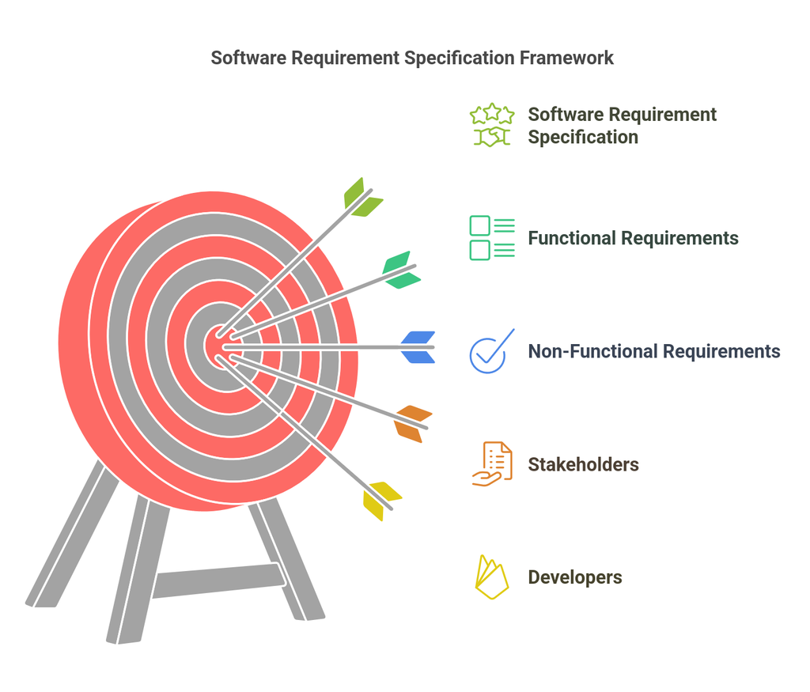

**🔹 Scenario:**  
A **hospital management system** 🏥 requires an **SRS document** to define patient record storage, doctor schedules, and data security. Without it, **miscommunication could lead to errors** in software development.

## **⚡ Types of Software Requirements**

### **1️⃣ Functional Requirements ⚙️ (What the system should do)**

- Define the **core functionality** of a system.
- Specify **data inputs, processing logic, and expected outputs**.
- Captured using **use cases, flowcharts, and structured text**.

**📌 Key Functional Requirements:**  
✅ **User Authentication** – Logging in securely. 🔐  
✅ **Data Processing** – Storing and retrieving data. 📊  
✅ **Business Logic Implementation** – Ensuring system rules. ⚖️  
✅ **User Interface Behavior** – Displaying data, alerts, etc. 🖥️

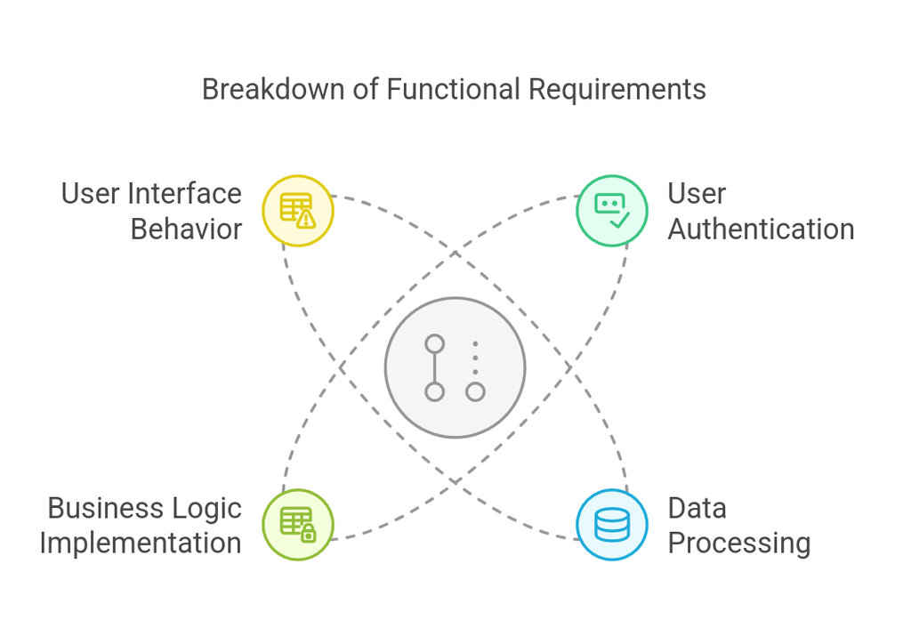

**🔹 Example:**  
An **e-commerce platform** 🛒 must allow users to **browse products, add to cart, and complete purchases** via a secure checkout process.

### **2️⃣ Non-Functional Requirements 🛡️ (How the system should perform)**

- Define **performance, security, reliability, and usability** constraints.
- Ensure **efficiency, maintainability, and fault tolerance**.

**📌 Key Non-Functional Requirements:**  
✅ **Security** – Data encryption and user authentication 🔐  
✅ **Performance** – Fast response times under load ⚡  
✅ **Interoperability** – Compatibility with other systems 🔄  
✅ **Disaster Recovery** – Backup and recovery solutions 🛠️

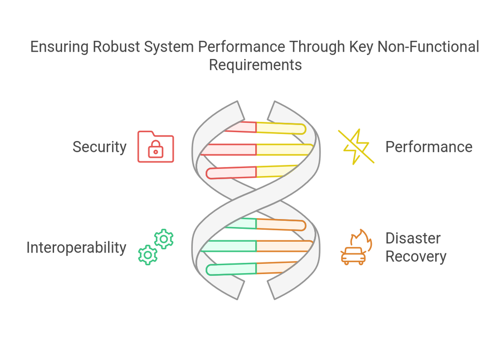

**🔹 Example:**  
A **banking system** 🏦 must **process transactions within 5 seconds** and **prevent unauthorized access** through multi-factor authentication.

## **📜 Software Requirement Specification (SRS)**

The **SRS document** serves as a **blueprint** 📑 for software development.

### **📍 Purpose of SRS:**

✔️ Ensures **all requirements are well-defined**.  
✔️ Helps developers **understand stakeholder needs**.  
✔️ Serves as a **reference for testing & validation**.

### **📌 Key Elements of SRS:**

1️⃣ **Functional & Non-Functional Requirements**  
2️⃣ **System Constraints & Limitations**  
3️⃣ **Performance & Usability Metrics**  
4️⃣ **External System Interactions**

**🔹 Scenario:**  
An **airline reservation system** ✈️ requires an **SRS document** defining **seat selection, ticket booking, and refund policies**. A well-defined SRS helps avoid conflicts between developers and stakeholders.

## **🔍 Characteristics of a Good SRS Document**

✔️ **Correctness** – Must accurately reflect user requirements.  
✔️ **Completeness** – Covers all aspects, leaving no ambiguity.  
✔️ **Consistency** – No conflicting requirements.  
✔️ **Unambiguousness** – Every requirement has a clear, single interpretation.  
✔️ **Modifiability** – Easily adaptable to changes.  
✔️ **Testability** – Enables validation through testing.  
✔️ **Traceability** – Links requirements to design and code.

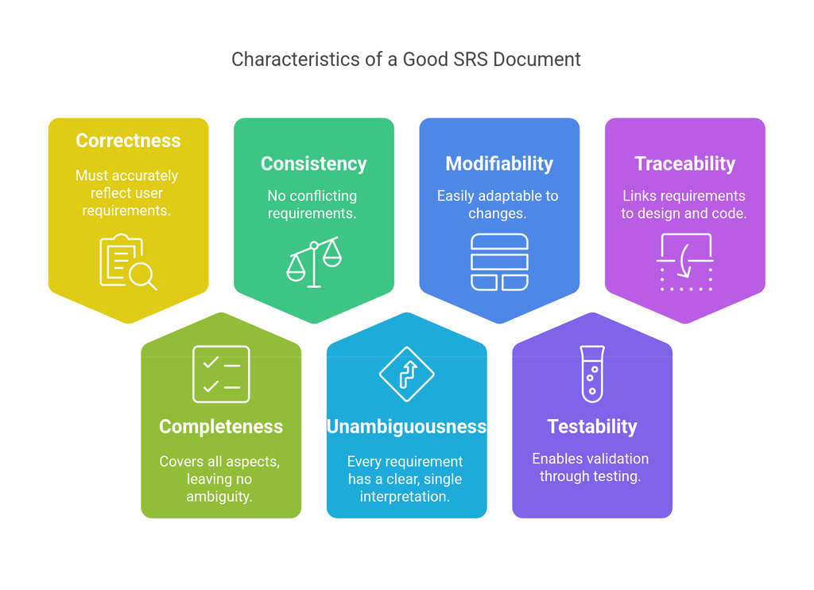

**🔹 Scenario:**  
A **ride-sharing app** 🚗 needs an SRS that includes **driver tracking, fare calculation, and safety features**. If **ambiguities exist**, developers may misunderstand user needs.

## **📌 Requirement Engineering Process**

Requirement Engineering involves **gathering, analyzing, and documenting software requirements** systematically.

### **📍 Steps in Requirement Engineering:**

1️⃣ **Feasibility Study** – Checks if the project is viable.  
2️⃣ **Requirement Gathering** – Identifies user needs via surveys, interviews, etc.  
3️⃣ **SRS Documentation** – Defines all requirements in a structured document.  
4️⃣ **Requirement Validation** – Ensures clarity, feasibility, and completeness.

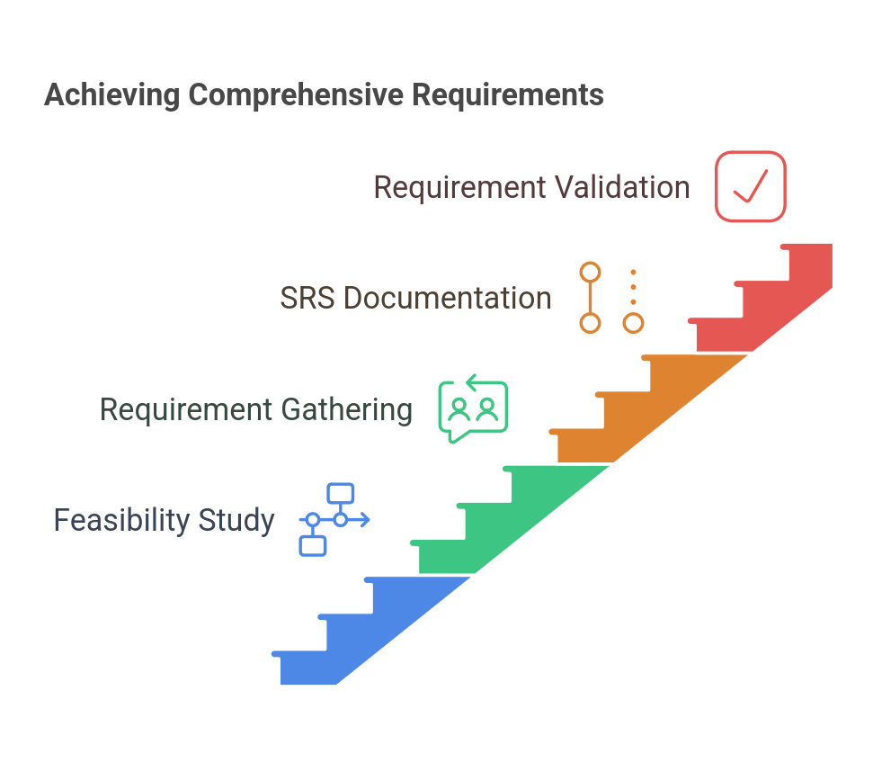

**🔹 Scenario:**  
A company developing an **AI chatbot** 🤖 first **analyzes feasibility**, then **gathers customer requirements**, documents them, and finally **validates if AI responses meet user expectations**.

## **📌 Requirement Elicitation Process**

Requirement elicitation ensures that developers **understand what users truly need**. It consists of:

1️⃣ **Gathering Requirements** – Identifying user needs.  
2️⃣ **Organizing Requirements** – Prioritizing based on importance.  
3️⃣ **Negotiation & Discussion** – Resolving conflicts between stakeholders.  
4️⃣ **Documentation** – Creating a formal requirement specification.

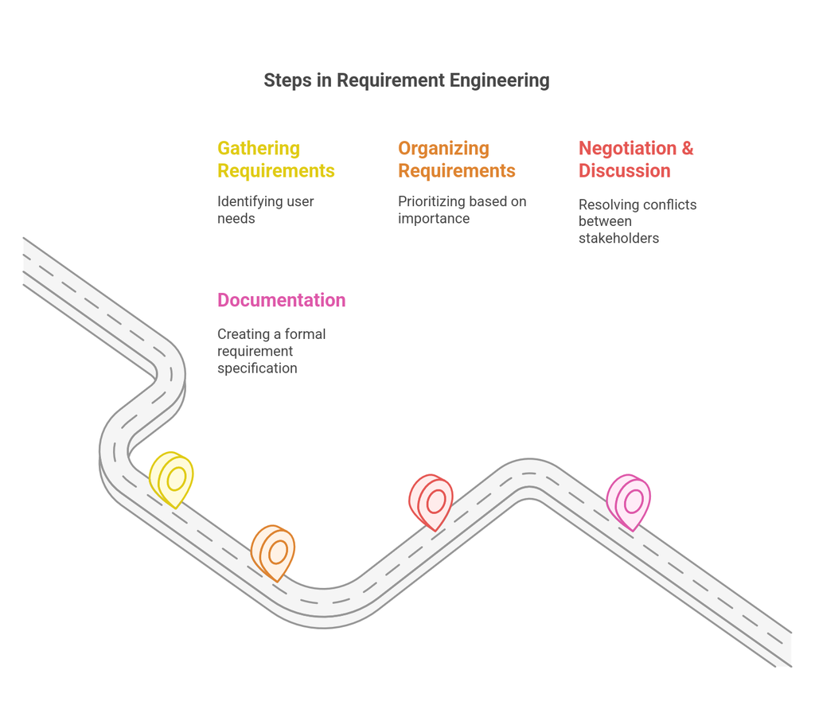

**🔹 Scenario:**  
A **hotel booking platform** 🏨 conducts interviews and surveys to **collect user expectations and prioritize key features like online payment, room selection, and cancellation policies**.

## **📌 Requirement Elicitation Techniques**

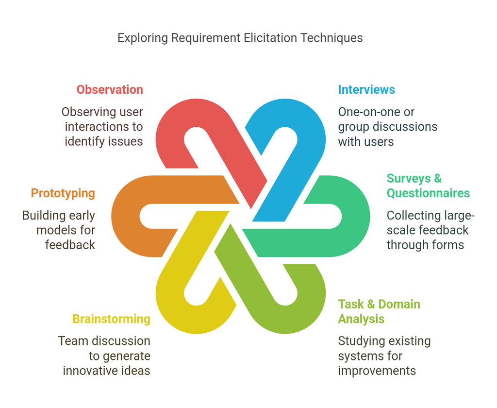

### **1️⃣ Interviews 🎤**

- One-on-one or group discussions with users.
- Can be **structured (predefined questions)** or **open-ended**.

**🔹 Scenario:**  
A **university** 🎓 interviews students and faculty to design a **course registration system** 📚.

### **2️⃣ Surveys & Questionnaires 📋**

- Collect large-scale feedback through structured forms.
- Helps in **prioritizing system features**.

**🔹 Scenario:**  
A **mobile banking app** 📱 conducts a survey to determine which features users **value the most**, like **bill payments or loan applications**.

### **3️⃣ Task & Domain Analysis 🔍**

- Studying **existing systems** to identify improvements.
- Uses **industry best practices** for reference.

**🔹 Scenario:**  
A **warehouse automation system** 🏭 analyzes current logistics to **optimize product tracking and storage management**.

### **4️⃣ Brainstorming 💡**

- A **team discussion** to generate innovative ideas.
- Encourages **creative problem-solving**.

**🔹 Scenario:**  
A **gaming company** 🎮 holds a brainstorming session to introduce **new multiplayer features** in their upcoming game.

### **5️⃣ Prototyping 🏗️**

- Builds an **early model** of the software for feedback.
- Helps in refining **user requirements** before final development.

**🔹 Scenario:**  
A **food delivery app** 🍔 develops a prototype to **test navigation, order tracking, and restaurant listings** before full-scale development.

### **6️⃣ Observation 👀**

- Directly observing **user interactions** with existing systems.
- Identifies **pain points and improvement areas**.

**🔹 Scenario:**  
An **airport management system** ✈️ observes **passenger check-in and baggage handling** to streamline operations.

## **🎯 Conclusion**

📌 **Requirement analysis ensures software meets user needs efficiently**.  
📌 **SRS serves as a contract between developers and stakeholders**.  
📌 **A structured elicitation process prevents misunderstandings and costly revisions**.

By following a **systematic approach**, software engineers **develop high-quality, efficient, and user-friendly systems**! 🚀